# Fredericton Transit Ridership Analysis

### Bus-Stop Usage Analysis

- The bus-stop usage analysis is performed to understand the popularity of the different bus stops among the transit users.
- This can lead to targeted improvements in the infrastructure and services provided at the most popular bus stops.
- King's Place and Regent Mall are the hubs at which most of the transit users board the buses. These are at downtown and uptown locations, respectively, and are likely to be the most popular boarding points due to their central locations. But what other places could be made hubs to increase the convenience of the transit service?

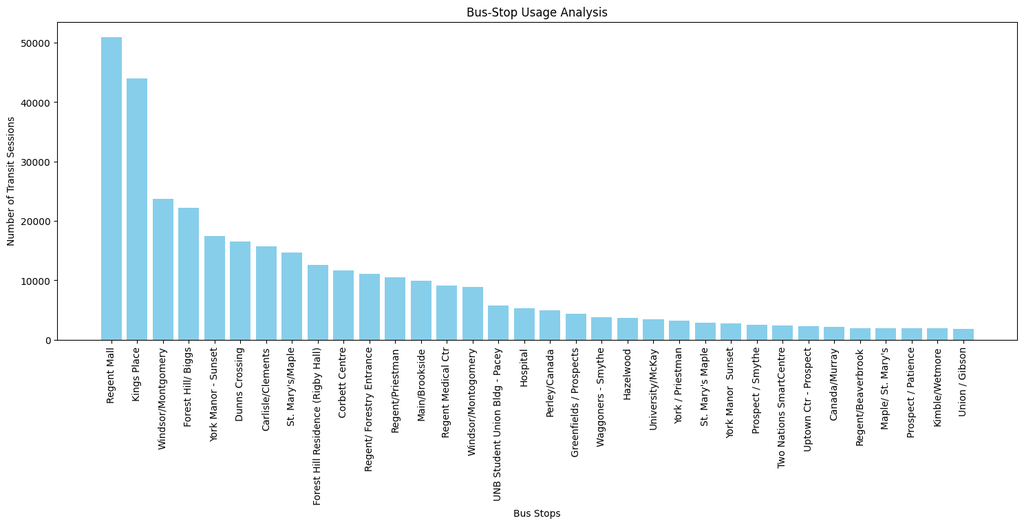

```python
# Calculate the number of times each bus stop was used by the transit users
bus_stop_usage = data[CONSTANTS.SESSION_ID].groupby(data['boarding_stop']).count().sort_values(ascending=False)
# Filter any bus stops with the lowest 50% of usage, as this increases the readability of the plot while retaining the most popular bus stops and therefore the most impactful information
bus_stop_usage = bus_stop_usage[bus_stop_usage > bus_stop_usage.median()].to_dict()
# Plot the Bus-Stop Usage Analysis
UTILITIES.plot_bar_chart(bus_stop_usage, 'Bus-Stop Usage Analysis', 'Bus Stops', 'Number of Transit Sessions')
```

Apart from King's Place and Regent Mall, the most popular bus stops are:

- **Windsor/Montgomery** - This bus stop is located right next to University of New Brunswick(UNB) and is likely to be popular among students. This indicates that the bus service is being **used by students** to commute to and from the university to a significant extent.
- **Forest Hill/Biggs** - This bus stop is located near the student residences and is likely to be popular among students living in that area. This is further evidence of the **popularity of the bus service among students**.

It is clear that the bus service is being used by students to a significant extent, and this information can be used to make targeted decisions to improve the service for this demographic.

## Understanding Transit User Preferences

- The data is pivoted on 3 main attributes, which will help understand the following:
  1. **Route** - Understanding the most popular routes for each user.
  2. **Part of the Day** - Understanding the most popular times of the day for each user.
  3. **Boarding Stop** - Understanding the most popular boarding stops for each user.
- This will help in understanding the user preferences through the data.

```python
# Calculate the number of times a single user has boarded a bus for each Route,the Part of the Day in which they boarded, and Boarding Stop they used
route_pivoted = pd.crosstab(data['user_id'], data['route'])
part_of_day_pivoted = pd.crosstab(data['user_id'], data['part_of_day'])
boarding_counts = pd.crosstab(data['user_id'], data['boarding_stop'])
# Combine the pivoted dataframes on 'user_id' in a single operation
user_transit_pattern = pd.concat([route_pivoted, part_of_day_pivoted, boarding_counts], axis=1)
# Drop any NaN values in-place
user_transit_pattern.dropna(inplace=True)
```

## Clustering of Transit Users based on their Transit Patterns

The data is clustered using the **K-Means Clustering Algorithm** to group the users based on their transit patterns. This will help in understanding the different user groups and their preferences. And, consequently, help in making targeted decisions to improve the transit service.

Transit Ridership is **measured mainly on overall user-base satisfaction**, with each user bringing in **roughly the same revenue per ride as well as only one class of users** existing, unlike an airline. The overall satisfaction of the user base is more important than the satisfaction of individual users. The goal is to increase the number of users and the number of rides per user, which will increase the overall ridership.

### **Elbow Method** to find the optimal number of clusters:

- The Elbow Method calculates the sum of squared distances between the data points and their assigned clusters' centroids for different values of K.
- A Silhouette Score is calculated for each K, which is a measure of how similar an object is to its cluster compared to other clusters.
- The K with the highest Silhouette Score is considered the optimal number of clusters.

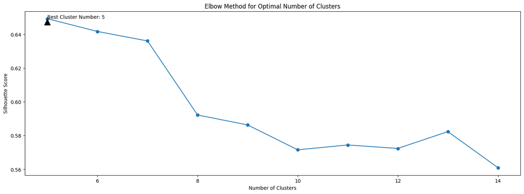

```python
# Finding the best random state and cluster number
best_kmeans = None
best_k = None
silhouette_scores = {}
cluster_range = range(5, 15)
for k in cluster_range:
    kmeans = KMeans(n_clusters=k, random_state=CONSTANTS.RANDOM_SEED)
    kmeans.fit(user_transit_pattern)
    silhouette_score = metrics.silhouette_score(user_transit_pattern, kmeans.labels_)
    silhouette_scores[k] = silhouette_score
# Find the best cluster number
best_k = max(silhouette_scores, key=silhouette_scores.get)
plt.figure(figsize=(18, 6))
plt.plot(silhouette_scores.keys(), silhouette_scores.values(), marker='o')
# Annotate the best cluster number
plt.annotate(f'Best Cluster Number: {best_k}', xy=(best_k, silhouette_scores[best_k]),
             xytext=(best_k, silhouette_scores[best_k]),
             arrowprops=dict(facecolor='black', shrink=0.5))
plt.title('Elbow Method for Optimal Number of Clusters')
plt.xlabel('Number of Clusters')
plt.ylabel('Silhouette Score')
plt.show()
```

## Fit the Best K-Means Model and Assign Cluster Labels to the Users

- The best K-Means model is fitted using the optimal number of clusters obtained from the Elbow Method.
- The cluster labels are then assigned to the users based on this model.

```python
kmeans_clustering_model = KMeans(n_clusters=best_k
                 , random_state=CONSTANTS.RANDOM_SEED)
kmeans_clustering_model.fit(user_transit_pattern)
cluster_labels = kmeans_clustering_model.labels_
user_transit_pattern['Cluster'] = cluster_labels
```

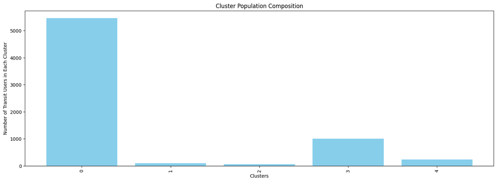

```python
# Find the number of Transit Users that belong to each of the Clusters
cluster_counts = user_transit_pattern['Cluster'].value_counts().to_dict()
# Visualize the number of users in each cluster
UTILITIES.plot_bar_chart(cluster_counts, 'Cluster Population Composition', 'Clusters' ,'Number of Transit Users in Each Cluster')
```

## Visualizing the Clusters using Parallel Coordinates

- The clusters are visualized using Parallel Coordinates to understand the transit patterns of each cluster.

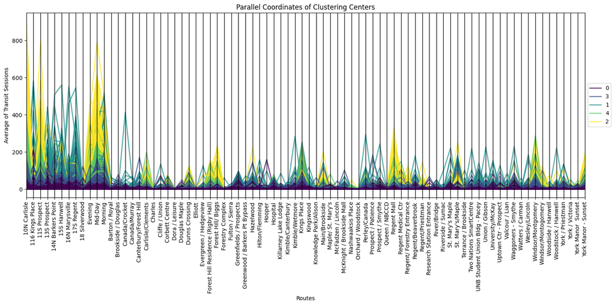

```python
UTILITIES.plot_parallel_coordinates(user_transit_pattern,
                                    title="Parallel Coordinates of Clustering Centers",
                                    x_label='Routes',
                                    y_label='Average of Transit Sessions')
```

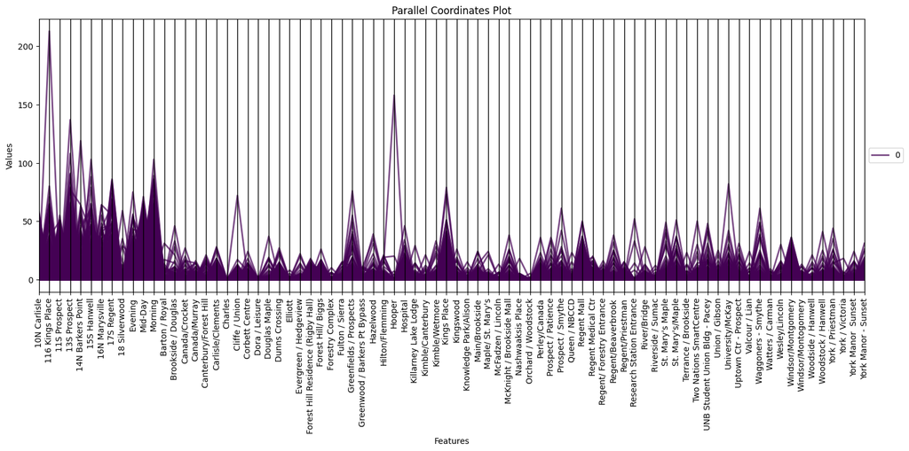

```python
# Choosing only one cluster for visualization: Cluster 0
cluster = 0
cluster_specific_user_transit_pattern = user_transit_pattern[user_transit_pattern['Cluster']== cluster]
UTILITIES.plot_parallel_coordinates(cluster_specific_user_transit_pattern)
```

## Inter-Day Bus Usage of the Cluster-Specific Users

- The inter-day bus usage of the cluster-specific users is calculated to understand the hourly bus usage of the users for each day of the week.
- Per-day bus usage is useful in understanding the daily patterns of the users. And, has the necessary level of granularity to make targeted decisions about the bus schedules.

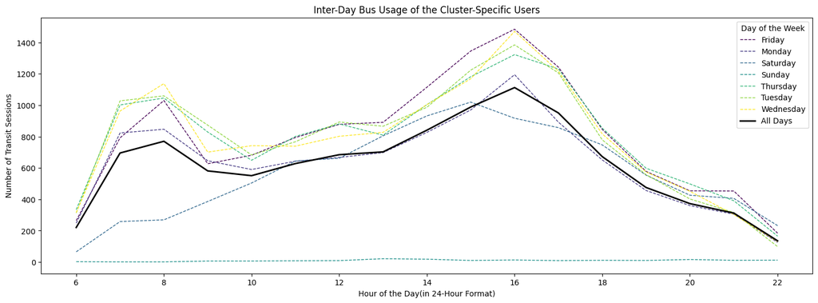

```python
# Find the Inter-Day Bus Usage of the Cluster-Specific Users
cluster_specific_users = data[data['user_id'].isin(cluster_specific_user_transit_pattern.index)]
# Calculate the hourly bus usage of the cluster-specific users for each day of the week
hourly_bus_usage = cluster_specific_users.groupby([cluster_specific_users[CONSTANTS.START_TIME].dt.hour, 'day_of_week'])['session_id'].count().unstack()
# Find the mean line that is the average hourly bus usage of the cluster-specific user for all days of the week
hourly_bus_usage['all_days'] = hourly_bus_usage.mean(axis=1)
# Plotting the hourly bus usage of the cluster-specific users
fig, ax = plt.subplots(figsize=(18, 6))
hourly_bus_usage.drop('all_days', axis=1).plot(ax=ax, colormap='viridis', linestyle='dashed', linewidth=1)
hourly_bus_usage['all_days'].plot(ax=ax, color='black', linestyle='solid', label='All Days', linewidth=2)
ax.set_xlabel('Hour of the Day(in 24-Hour Format)')
ax.set_ylabel('Number of Transit Sessions')
ax.set_title('Inter-Day Bus Usage of the Cluster-Specific Users')
ax.legend(title='Day of the Week')
plt.show()
```